# CardioGoodFitness_Project

## Check relation between fitness, usage and product.

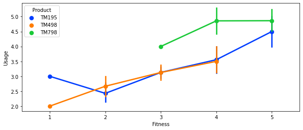

```python
plt.figure(figsize=(10,4))
sns.pointplot(x='Fitness',y='Usage', data=df,hue='Product',palette='bright')
plt.show()
```

### Observation

1. Customers who rate themselves high prefer to use TM798
2. Customers who rate themselves low prefer to use TM195

## Check correlation between Usage, Miles and Product.

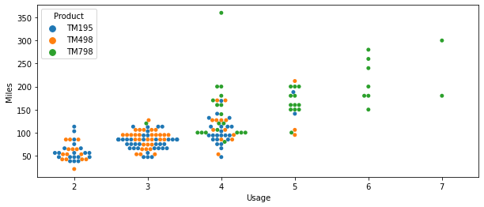

```python
plt.figure(figsize=(10,4))
sns.swarmplot(x='Usage',y='Miles', data=df,hue='Product',palette='tab10');
```

### Observation

1. Customers who use TM798 tend to run more miles
2. Customers who use TM195 run less miles

## Check relation between Usage, Income and Product.

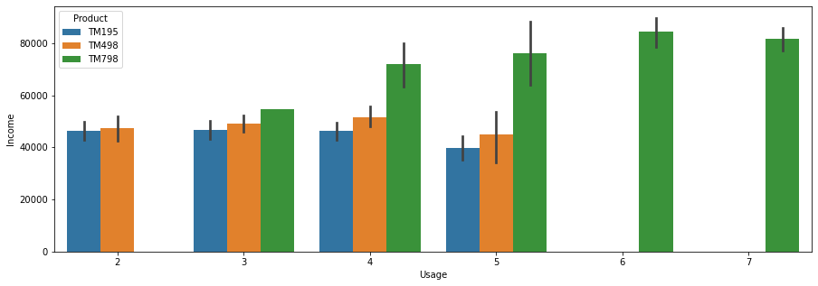

```python
fig = plt.figure(figsize= (15,5))
ax = sns.barplot(x ='Usage', y = 'Income', data = df, hue = 'Product')
```

### Observation

1. Customers with higher income use TM798
2. Customers with less income prefer to use TM498 and TM195

## Check relation between Gender, usage and product.

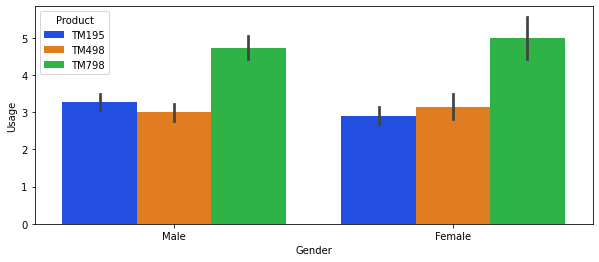

```python
plt.figure(figsize=(10,4))
sns.barplot(x='Gender',y='Usage', data=df,hue='Product',palette='bright')
plt.show()
```

### Observation

1. Customers (Both Male and Female) whose usage is high prefer to use TM798 and lesser usage prefer to use TM195 and TM498 respectively

# distribution of plot across each Product - violin plot

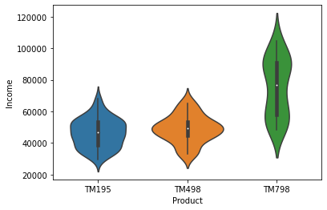

```python
 ax = sns.violinplot(x =data.Product, y = data['Income'])
```

### Observation

1. Low income customers prefer TM195,TM498 over TM798

```python
from pandas_profiling import ProfileReport
# Use the original dataframe, so that original features are considered
prof_df = ProfileReport(df)
# to view report created by pandas profile
prof_df
```

[interactive chart not shown]

# Conclusion and Recommendations

## Conclusion

Analyzed the data of nearly 180 customers of the treadmill product(s) of a retail store called Cardio Good Fitness. The main feature of interest here is the Product. From the Analysis, we observe that

1. Most of the customers fall in the age group 24-27 years.
2. most of the customers have 14- 16 years of experience.
3. Most of the customers want to use the threadmill for 3-4times/week.
4. The Income of majority of the customers falls between (40000-60000)
5. Customers busying the equipment are mostly Men.

1. Customers with higher income, those who prefer to run more miles and whose fitness rating is higher prefer to use TM798.
2. Customers with lower income, medium usage and less years of education prefer TM498.
3. Customers with less fitness rating, lesser miles and lower Income prefer TM195.

### Recommendations

1. Make TM798 a premium product. Increase more features like inbuilt TV, fitness monitor,etc. Scope for increasing price and thus increase margins.
2. TM498 should be a mid range product. Keep price lower than the premium but offer better features than TM195. Survey TM498 users to understand must have and nice to have features and introduce features accordingly.
3. Decrease cost of TM195 by using cheaper materials and using local manufaturing. Keep just basic features in this model. This should be marketed as entry point product for all fitness enthusiasts. Introduce promotions/sales during major events